> **Tip**: Welcome to the Investigate a Dataset project! You will find tips in quoted sections like this to help organize your approach to your investigation. Before submitting your project, it will be a good idea to go back through your report and remove these sections to make the presentation of your work as tidy as possible. First things first, you might want to double-click this Markdown cell and change the title so that it reflects your dataset and investigation.

# Project: Investigate a European Soccer Database

- Introduction
- Data Wrangling
- Exploratory Data Analysis
- Conclusions

## Introduction

> Lets assume that a boss frm Midde East ring me and give me 2 billion dollars. In which, I have to build a club in Euro & build dream teams from scratch. Base on the database given by Kaggle, I will turn it into something more meaningfull to me. So, There are few questions need to be answered are:
> 1. Which club should I buy. The club should not be the most popular but somehow on the top, interm on media attraction. So, I set the range based on the matchs the club plays & total goals
> 2. Which player should I buy? I will pick them up from top of the players, based on their field: attacker, play makers, defence and goal keeper

```python
# Use this cell to set up import statements for all of the packages that you
#   plan to use.
import sqlite3
import numpy as np

# Pandas for DataFrames
import pandas as pd
pd.set_option('display.max_columns', 100)

# Matplotlib for visualization
from matplotlib import pyplot as plt
# display plots in the notebook
%matplotlib inline

# Seaborn for easier visualization
import seaborn as sns
# Remember to include a 'magic word' so that your visualizations are plotted
#   inline with the notebook. See this page for more:
#   http://ipython.readthedocs.io/en/stable/interactive/magics.html
```

## Data Wrangling

> **Tip**: In this section of the report, you will load in the data, check for cleanliness, and then trim and clean your dataset for analysis. Make sure that you document your steps carefully and justify your cleaning decisions.

### General Properties

```python
# Load your data and print out a few lines. Perform operations to inspect data
#   types and look for instances of missing or possibly errant data.
#import database
with sqlite3.connect ('database.sqlite') as dbs:
    df_country =pd.read_sql_query("SELECT * FROM Country", dbs)
    df_match=pd.read_sql_query("SELECT * FROM Match", dbs)
    df_league=pd.read_sql_query("SELECT * FROM League", dbs)
    df_team=pd.read_sql_query("SELECT * FROM Team", dbs)
    df_player=pd.read_sql_query("SELECT * FROM Player", dbs)
    df_player_atr=pd.read_sql_query("SELECT * FROM Player_Attributes", dbs)
    df_sequence=pd.read_sql_query("SELECT * FROM sqlite_sequence", dbs)
    df_team_atr=pd.read_sql_query("SELECT * FROM Team_Attributes", dbs)
```

## Data introduction

> The data source has been extracted into 7 tables:

> Table Name Table Description

> 1.df_country A table containing the country name of soccer teams

> 2.df_league A table containing the name of all the soccer leagues

> 3.df_match A table containing all the match details from 2007 to 2016

> 4.df_player A table containing all player ID and player name for all the teams

> 5.df_player_atr A table containing additional information of all the players such as attacking ability, defensive ability, strength, etc.

> 6.df_team A table containing all the team ID and team name

> 7.df_team_atr A table containing additional information of all the teams such as their attacking and defensive ability, etc.

> **Tip**: In this section of the report, you will load in the data, check for cleanliness, and then trim and clean your dataset for analysis. Make sure that you document your steps carefully and justify your cleaning decisions.

### So, the raw data has been loaded into system. Here is step I am going to do to clean up & get data remediation

> **Tip**: You should *not* perform too many operations in each cell. Create cells freely to explore your data. One option that you can take with this project is to do a lot of explorations in an initial notebook. These don't have to be organized, but make sure you use enough comments to understand the purpose of each code cell. Then, after you're done with your analysis, create a duplicate notebook where you will trim the excess and organize your steps so that you have a flowing, cohesive report.

> **Tip**: Make sure that you keep your reader informed on the steps that you are taking in your investigation. Follow every code cell, or every set of related code cells, with a markdown cell to describe to the reader what was found in the preceding cell(s). Try to make it so that the reader can then understand what they will be seeing in the following cell(s).

### Data Cleaning (Data inspection for each of table and get rid of unwanted cols & objects)

```python
#Data review
df_country.head(5)
df_league.head(5)
df_match.head(5)
df_player.head(5)
df_player_atr.head(5)
df_team.head(5)
df_team_atr.head(5)
```

[output not shown]

```python
#Country data inspection:
df_country.describe()
```

|  | id |
| --- | --- |
| count | 11.000000 |
| mean | 12452.090909 |
| std | 8215.308472 |
| min | 1.000000 |
| 25% | 6289.000000 |
| 50% | 13274.000000 |
| 75% | 18668.000000 |
| max | 24558.000000 |

```python
#League data inspection
df_league.head(10)
```

|  | id | country_id | name |
| --- | --- | --- | --- |
| 0 | 1 | 1 | Belgium Jupiler League |
| 1 | 1729 | 1729 | England Premier League |
| 2 | 4769 | 4769 | France Ligue 1 |
| 3 | 7809 | 7809 | Germany 1. Bundesliga |
| 4 | 10257 | 10257 | Italy Serie A |
| 5 | 13274 | 13274 | Netherlands Eredivisie |
| 6 | 15722 | 15722 | Poland Ekstraklasa |
| 7 | 17642 | 17642 | Portugal Liga ZON Sagres |
| 8 | 19694 | 19694 | Scotland Premier League |
| 9 | 21518 | 21518 | Spain LIGA BBVA |

```python
df_league.describe()
```

|  | id | country_id |
| --- | --- | --- |
| count | 11.000000 | 11.000000 |
| mean | 12452.090909 | 12452.090909 |
| std | 8215.308472 | 8215.308472 |
| min | 1.000000 | 1.000000 |
| 25% | 6289.000000 | 6289.000000 |
| 50% | 13274.000000 | 13274.000000 |
| 75% | 18668.000000 | 18668.000000 |
| max | 24558.000000 | 24558.000000 |

```python
#All country & league data are in good. So, we have nothing to do with those
```

```python
#Merge country and league table
df_country.shape
df_league.shape
df_coutry_league = df_country.merge(df_league, left_on='id', right_on='country_id',how="outer")
df_coutry_league.head(5)
df_coutry_league = df_coutry_league.drop("id_y",axis=1)
df_coutry_league=df_coutry_league.rename(columns={'id_x':'id','name_x':'Country', 'name_y':'League'})
```

```python
df_coutry_league.dtypes.index
```

```
Index(['id', 'Country', 'country_id', 'League'], dtype='object')
```

```python
#Team data inspection
df_match.head()
```

|  | id | country_id | league_id | season | stage | date | match_api_id | home_team_api_id | away_team_api_id | home_team_goal | away_team_goal | home_player_X1 | home_player_X2 | home_player_X3 | home_player_X4 | home_player_X5 | home_player_X6 | home_player_X7 | home_player_X8 | home_player_X9 | home_player_X10 | home_player_X11 | away_player_X1 | away_player_X2 | away_player_X3 | away_player_X4 | away_player_X5 | away_player_X6 | away_player_X7 | … |
| --- | --- | --- | --- | --- | --- | --- | --- | --- | --- | --- | --- | --- | --- | --- | --- | --- | --- | --- | --- | --- | --- | --- | --- | --- | --- | --- | --- | --- | --- | --- |
| 0 | 1 | 1 | 1 | 2008/2009 | 1 | 2008-08-17 00:00:00 | 492473 | 9987 | 9993 | 1 | 1 | NaN | NaN | NaN | NaN | NaN | NaN | NaN | NaN | NaN | NaN | NaN | NaN | NaN | NaN | NaN | NaN | NaN | NaN | … |
| 1 | 2 | 1 | 1 | 2008/2009 | 1 | 2008-08-16 00:00:00 | 492474 | 10000 | 9994 | 0 | 0 | NaN | NaN | NaN | NaN | NaN | NaN | NaN | NaN | NaN | NaN | NaN | NaN | NaN | NaN | NaN | NaN | NaN | NaN | … |
| 2 | 3 | 1 | 1 | 2008/2009 | 1 | 2008-08-16 00:00:00 | 492475 | 9984 | 8635 | 0 | 3 | NaN | NaN | NaN | NaN | NaN | NaN | NaN | NaN | NaN | NaN | NaN | NaN | NaN | NaN | NaN | NaN | NaN | NaN | … |
| 3 | 4 | 1 | 1 | 2008/2009 | 1 | 2008-08-17 00:00:00 | 492476 | 9991 | 9998 | 5 | 0 | NaN | NaN | NaN | NaN | NaN | NaN | NaN | NaN | NaN | NaN | NaN | NaN | NaN | NaN | NaN | NaN | NaN | NaN | … |
| 4 | 5 | 1 | 1 | 2008/2009 | 1 | 2008-08-16 00:00:00 | 492477 | 7947 | 9985 | 1 | 3 | NaN | NaN | NaN | NaN | NaN | NaN | NaN | NaN | NaN | NaN | NaN | NaN | NaN | NaN | NaN | NaN | NaN | NaN | … |

5 rows × 115 columns

```python
df_match.dtypes.index
```

```
Index(['id', 'country_id', 'league_id', 'season', 'stage', 'date',
       'match_api_id', 'home_team_api_id', 'away_team_api_id',
       'home_team_goal',
       ...
       'SJA', 'VCH', 'VCD', 'VCA', 'GBH', 'GBD', 'GBA', 'BSH', 'BSD', 'BSA'],
      dtype='object', length=115)
```

> There are quite a lot of unrelevant objects in this data table. So, we have to get rif of unwanted cols

```python
#Remove unwanted columns from teams table
#df_match.dtypes.index
df_match_selected = df_match[['id', 'country_id', 'league_id', 'season', 'stage', 'date',
                   'match_api_id', 'home_team_api_id', 'away_team_api_id',
                    'home_team_goal', 'away_team_goal']]

df_match_selected = df_match_selected.drop("id",axis=1)
```

```python
df_match_selected.dtypes.index
```

```
Index(['country_id', 'league_id', 'season', 'stage', 'date', 'match_api_id',
       'home_team_api_id', 'away_team_api_id', 'home_team_goal',
       'away_team_goal'],
      dtype='object')
```

```python
df_match_selected.duplicated().sum()
```

```
0
```

```python
df_match_selected.isnull().sum()
```

```
country_id          0
league_id           0
season              0
stage               0
date                0
match_api_id        0
home_team_api_id    0
away_team_api_id    0
home_team_goal      0
away_team_goal      0
dtype: int64
```

> There is nothing to do to improve the quality of match data but remove unrelevant cols

```python
#Merge counrtry, league and match
df_cou_lea_mat = df_match_selected.merge(df_coutry_league,left_on='country_id',right_on='country_id',how="outer")
df_cou_lea_mat = df_cou_lea_mat.drop("id",axis = 1)
df_cou_lea_mat = df_cou_lea_mat.rename(columns={'name_x':"country", 'name_y':"league"})
```

```python
df_cou_lea_mat.dtypes.index
```

```
Index(['country_id', 'league_id', 'season', 'stage', 'date', 'match_api_id',
       'home_team_api_id', 'away_team_api_id', 'home_team_goal',
       'away_team_goal', 'Country', 'League'],
      dtype='object')
```

```python
#Merge country, league, match and team data
df_cou_lea_mat_team=df_cou_lea_mat.merge(df_team,left_on="home_team_api_id",right_on="team_api_id",how="left")
df_cou_lea_mat_team.head(3)
df_cou_lea_mat_team = df_cou_lea_mat_team.drop(["id","team_api_id",'team_fifa_api_id'],axis = 1)
df_cou_lea_mat_team = df_cou_lea_mat_team.rename(columns={'team_long_name':'hteam_lname','team_short_name':'hteam_sname'})
#Merge away team
df_cou_lea_mat_team=df_cou_lea_mat_team.merge(df_team,left_on="away_team_api_id",right_on="team_api_id",how="left")
df_cou_lea_mat_team.head()
df_cou_lea_mat_team = df_cou_lea_mat_team.drop(["id","team_api_id",'team_fifa_api_id'],axis = 1)
df_cou_lea_mat_team = df_cou_lea_mat_team.rename(columns={ 'team_long_name':"ateam_lname",'team_short_name':"steam_sname"})
```

> The final outcome is merged data of country, league, match and team. Lets review about the final data:

```python
df_cou_lea_mat_team.head()
```

|  | country_id | league_id | season | stage | date | match_api_id | home_team_api_id | away_team_api_id | home_team_goal | away_team_goal | Country | League | hteam_lname | hteam_sname | ateam_lname | steam_sname |
| --- | --- | --- | --- | --- | --- | --- | --- | --- | --- | --- | --- | --- | --- | --- | --- | --- |
| 0 | 1 | 1 | 2008/2009 | 1 | 2008-08-17 00:00:00 | 492473 | 9987 | 9993 | 1 | 1 | Belgium | Belgium Jupiler League | KRC Genk | GEN | Beerschot AC | BAC |
| 1 | 1 | 1 | 2008/2009 | 1 | 2008-08-16 00:00:00 | 492474 | 10000 | 9994 | 0 | 0 | Belgium | Belgium Jupiler League | SV Zulte-Waregem | ZUL | Sporting Lokeren | LOK |
| 2 | 1 | 1 | 2008/2009 | 1 | 2008-08-16 00:00:00 | 492475 | 9984 | 8635 | 0 | 3 | Belgium | Belgium Jupiler League | KSV Cercle Brugge | CEB | RSC Anderlecht | AND |
| 3 | 1 | 1 | 2008/2009 | 1 | 2008-08-17 00:00:00 | 492476 | 9991 | 9998 | 5 | 0 | Belgium | Belgium Jupiler League | KAA Gent | GEN | RAEC Mons | MON |
| 4 | 1 | 1 | 2008/2009 | 1 | 2008-08-16 00:00:00 | 492477 | 7947 | 9985 | 1 | 3 | Belgium | Belgium Jupiler League | FCV Dender EH | DEN | Standard de Liège | STL |

```python
df_cou_lea_mat_team.shape
```

```
(25979, 16)
```

```python
df_cou_lea_mat_team.dtypes.index
```

```
Index(['country_id', 'league_id', 'season', 'stage', 'date', 'match_api_id',
       'home_team_api_id', 'away_team_api_id', 'home_team_goal',
       'away_team_goal', 'Country', 'League', 'hteam_lname', 'hteam_sname',
       'ateam_lname', 'steam_sname'],
      dtype='object')
```

```python
df_cou_lea_mat_team.duplicated().sum()
```

```
0
```

```python
df_cou_lea_mat_team.isnull().sum()
```

```
country_id          0
league_id           0
season              0
stage               0
date                0
match_api_id        0
home_team_api_id    0
away_team_api_id    0
home_team_goal      0
away_team_goal      0
Country             0
League              0
hteam_lname         0
hteam_sname         0
ateam_lname         0
steam_sname         0
dtype: int64
```

> The final outcome is all good

```python
#data player inspection
df_player.describe()
```

|  | id | player_api_id | player_fifa_api_id | height | weight |
| --- | --- | --- | --- | --- | --- |
| count | 11060.000000 | 11060.000000 | 11060.000000 | 11060.000000 | 11060.000000 |
| mean | 5537.511392 | 156582.427215 | 165664.910488 | 181.867445 | 168.380289 |
| std | 3197.692647 | 160713.700624 | 58649.928360 | 6.369201 | 14.990217 |
| min | 1.000000 | 2625.000000 | 2.000000 | 157.480000 | 117.000000 |
| 25% | 2767.750000 | 35555.500000 | 151889.500000 | 177.800000 | 159.000000 |
| 50% | 5536.500000 | 96619.500000 | 184671.000000 | 182.880000 | 168.000000 |
| 75% | 8306.250000 | 212470.500000 | 203883.250000 | 185.420000 | 179.000000 |
| max | 11075.000000 | 750584.000000 | 234141.000000 | 208.280000 | 243.000000 |

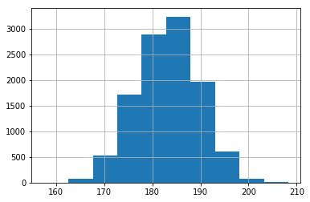

```python
df_player.height.hist()
```

```python
df_player["weight_kg"] = df_player["weight"] * 0.453592
df_player["height_m"]  = df_player["height"] / 100
df_player["bmi"]       = df_player["weight_kg"]/(df_player["height_m"] * df_player["height_m"])
df_player["year"]  = pd.DatetimeIndex(df_player["birthday"]).year
df_player["age"]   = 2018 - df_player["year"]
df_player=df_player.drop(['height','birthday','weight'],axis=1)
cols  = ["bmi","weight_kg","height_m","age"]
```

> Check histogram of height & weight to see they are in good range:

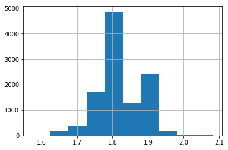

```python
df_player.height_m.hist()
```

> Fig 2: The height in m

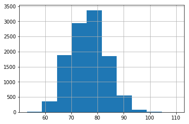

```python
df_player.weight_kg.hist()
```

> Fig 3: The weight in kg

```python
#Check data duplication:
df_player.duplicated().sum()
```

```
0
```

```python
#Check null data
df_player.isnull().sum()
```

```
id                    0
player_api_id         0
player_name           0
player_fifa_api_id    0
weight_kg             0
height_m              0
bmi                   0
year                  0
age                   0
dtype: int64
```

> Player data is all good at the moment

```python
#Player attribute inspection:
df_player_atr.dtypes.index
```

```
Index(['id', 'player_fifa_api_id', 'player_api_id', 'date', 'overall_rating',
       'potential', 'preferred_foot', 'attacking_work_rate',
       'defensive_work_rate', 'crossing', 'finishing', 'heading_accuracy',
       'short_passing', 'volleys', 'dribbling', 'curve', 'free_kick_accuracy',
       'long_passing', 'ball_control', 'acceleration', 'sprint_speed',
       'agility', 'reactions', 'balance', 'shot_power', 'jumping', 'stamina',
       'strength', 'long_shots', 'aggression', 'interceptions', 'positioning',
       'vision', 'penalties', 'marking', 'standing_tackle', 'sliding_tackle',
       'gk_diving', 'gk_handling', 'gk_kicking', 'gk_positioning',
       'gk_reflexes'],
      dtype='object')
```

```python
#Check data duplication
df_player_atr.duplicated().sum()
```

```
0
```

```python
#Check data null
df_player_atr.isnull().sum()
```

```
id                        0
player_fifa_api_id        0
player_api_id             0
date                      0
overall_rating          836
potential               836
preferred_foot          836
attacking_work_rate    3230
defensive_work_rate     836
crossing                836
finishing               836
heading_accuracy        836
short_passing           836
volleys                2713
dribbling               836
curve                  2713
free_kick_accuracy      836
long_passing            836
ball_control            836
acceleration            836
sprint_speed            836
agility                2713
reactions               836
balance                2713
shot_power              836
jumping                2713
stamina                 836
strength                836
long_shots              836
aggression              836
interceptions           836
positioning             836
vision                 2713
penalties               836
marking                 836
standing_tackle         836
sliding_tackle         2713
gk_diving               836
gk_handling             836
gk_kicking              836
gk_positioning          836
gk_reflexes             836
dtype: int64
```

> So, null data should be removed

```python
df_player_atr=df_player_atr.dropna(inplace=True)
```

```python
#Re-check null data
df_player_atr.isnull().sum()
```

[output not shown]

> So, Player attribute is all good now

```python
#merge player data with player attributes
df_players_total=df_player_atr.merge(df_player,left_on="player_api_id",right_on="player_api_id",how="left")
```

```python
#List of objects in slect team table
for features in df_players_total.dtypes.index:
    print(features)
```

[output not shown]

```python
cols =["id_x","id_y",'player_fifa_api_id_y','height', 'weight', 'weight_kg', 'height_m', 'bmi', 'year','age','birthday']
df_players_total = df_players_total[[x for x in df_players_total.columns if x not in cols]]
df_players_total.columns
df_players_total = df_players_total.rename(columns={'player_fifa_api_id_x':'player_fifa_api_id'})
```

```python
df_players_total.dropna(inplace=True)
```

```python
#Write sort data to csv files
df_cou_lea_mat_team.to_csv('merged_team',index=False)
df_players_total.to_csv('merged_player',index=False)
```

## Exploratory Data Analysis

> **Tip**: Now that you've trimmed and cleaned your data, you're ready to move on to exploration. Compute statistics and create visualizations with the goal of addressing the research questions that you posed in the Introduction section. It is recommended that you be systematic with your approach. Look at one variable at a time, and then follow it up by looking at relationships between variables.

### Which club should I buy?

```python
# Use this cell to set up import statements for all of the packages that you
#   plan to use.
import numpy as np

# Pandas for DataFrames
import pandas as pd
pd.set_option('display.max_columns', 100)

# Matplotlib for visualization
from matplotlib import pyplot as plt
# display plots in the notebook
%matplotlib inline

# Seaborn for easier visualization
import seaborn as sns
```

```python
df_merged_team = pd.read_csv('merged_team')
```

```python
df_merged_player = pd.read_csv('merged_player')
```

```python
df_merged_team.shape
df_merged_team.dtypes.index
```

```
Index(['country_id', 'league_id', 'season', 'stage', 'date', 'match_api_id',
       'home_team_api_id', 'away_team_api_id', 'home_team_goal',
       'away_team_goal', 'Country', 'League', 'hteam_lname', 'hteam_sname',
       'ateam_lname', 'steam_sname'],
      dtype='object')
```

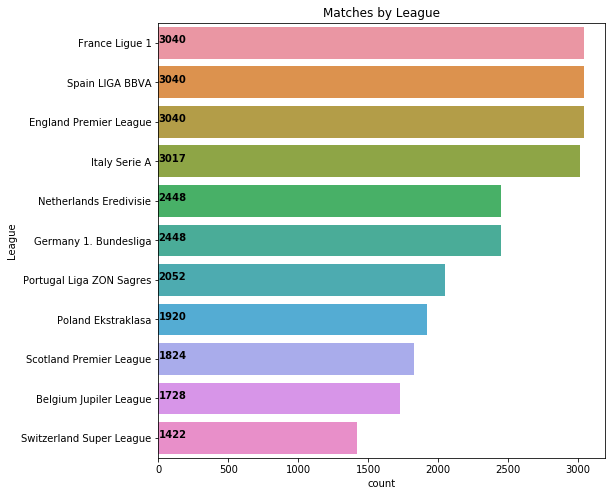

```python
#figure which leagues have the most matches
plt.figure(figsize=(8,8))
ax = sns.countplot(y = df_merged_team["League"],
                   order=df_merged_team["League"].value_counts().index,
                  )
for i,j in enumerate(df_merged_team["League"].value_counts().values):
    ax.text(.7,i,j,weight = "bold")
plt.title("Matches by League")
plt.show()
```

> Fig 4: The chart shows the total games each League in 8 years duration. The team I pick up should be in the top league which have much match to play.

```python
# Use this, and more code cells, to explore your data. Don't forget to add
#   Markdown cells to document your observations and findings.
#group teams based on the name & home/away goals
home_team = df_merged_team.groupby("hteam_lname")["home_team_goal"].sum().reset_index()
away_team = df_merged_team.groupby("ateam_lname")["away_team_goal"].sum().reset_index()
home_team = home_team.sort_values(by="home_team_goal",ascending= False)
away_team = away_team.sort_values(by="away_team_goal",ascending= False)
```

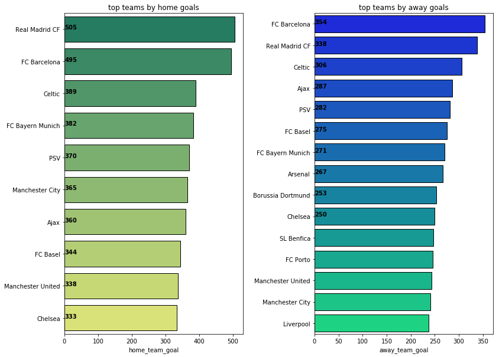

```python
#plot charts based on home/away goals
plt.figure(figsize=(13,10))
plt.subplot(121)
ax = sns.barplot(y="hteam_lname",x="home_team_goal",
                 data=home_team[:10],palette="summer",
                 linewidth = 1,edgecolor = "k"*20)
plt.ylabel('')
plt.title("top teams by home goals")
for i,j in enumerate(home_team["home_team_goal"][:10]):
    ax.text(.7,i,j,weight = "bold")
plt.subplot(122)
ax = sns.barplot(y="ateam_lname",x="away_team_goal",
                 data=away_team[:15],palette="winter",
                linewidth = 1,edgecolor = "k"*10)
plt.ylabel("")
plt.subplots_adjust(wspace = .4)
plt.title("top teams by away goals")
for i,j in enumerate(away_team["away_team_goal"][:10]):
    ax.text(.7,i,j,weight = "bold")
```

```python
# Find down the goals record by season
home_team_season = df_merged_team.groupby(["hteam_lname","season"])["home_team_goal"].sum().reset_index()
away_team_season = df_merged_team.groupby(["ateam_lname","season"])["away_team_goal"].sum().reset_index()
home_team_season = home_team_season.sort_values(by="home_team_goal",ascending= False)
away_team_season = away_team_season.sort_values(by="away_team_goal",ascending= False)
```

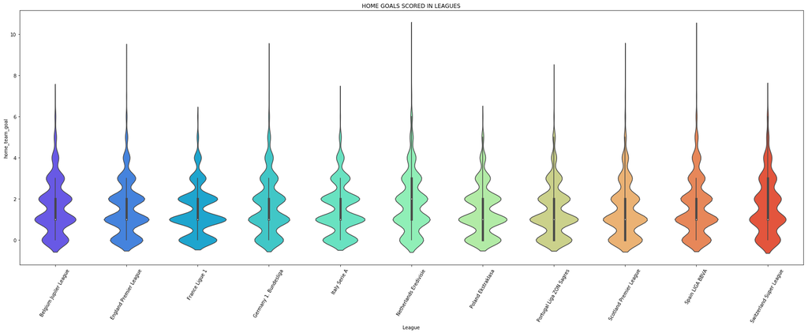

```python
#Find down home goals distribution in each league
plt.figure(figsize=(30,10))
sns.violinplot(df_merged_team["League"],df_merged_team["home_team_goal"],palette="rainbow")
plt.title("HOME GOALS SCORED IN LEAGUES")
plt.xticks(rotation = 60)
plt.show()
```

> Fig 6: The violin box shows the distribution of home goals each league.

[figure not shown]

```python
#Find down away goals distribution in each league
plt.figure(figsize=(30,10))
sns.violinplot(df_merged_team["League"],df_merged_team["home_team_goal"],palette="rainbow")
plt.title("AWAY GOALS SCORED IN LEAGUES")
plt.xticks(rotation = 60)
plt.show()
```